# From Data to Prediction: Modeling IPL Match Scores

Author

Aniket Gauba, Raiyan Islam

Published

May 2, 2024

# Introduction

In this project, we investigate how the number of wickets remaining and the number of overs left influence the runs scored in an Indian Premier League game. The Indian Premier League, also known as the IPL, is a professional Twenty20 cricket league in India. Cricket, a sport with a rich history and strategic depth, depends on making informed decisions during a match. By analyzing IPL match data from 2008 to 2023, we aim to develop a prediction model that forecasts run production based on current game conditions. This model can provide teams with actionable insights, helping them to strategize more effectively in real time and potentially change the outcome of the game. Accurate predictions of run production based on current match conditions can empower coaches and players with a deeper understanding of potential game progressions, facilitating strategic decisions such as optimizing batting orders and timing the use of key bowlers. Additionally, this model enhances fan engagement by offering a more immersive and interactive experience, as spectators can appreciate the complexities of strategy and probability playing out in real time.

We use an open-source R package called “cricketdata” to download the ball-by-ball data from Cricsheet, a collection of projects that provide various kinds of data regarding cricket. This way we get the data as a tibble ready for analysis. Our dataset, named “ipl”, allows us to examine how different game scenarios affect a team’s ability to score runs. It includes extensive variables that capture every aspect of the game, making it a powerful tool for building our predictive model. We will mostly be focusing on the variables “balls_remaining” and “wickets_remaining”, analyzing how these two variables affect the runs scored from any point of the game.

# Stakeholders and Ethical Considerations

Our analysis has the potential to impact a variety of stakeholders within the cricket world. Teams and players are directly affected by the predictions as it may influence their game strategy. Fans and the general public use this information for fantasy leagues and to gain a deeper understanding of the game. Cricket boards and regulatory bodies are interested in maintaining the integrity of the sport and ensuring fair play. Finally, data providers like the developers of the “cricket” R package have a stake in how their data is used.

With this in mind, we acknowledge the importance of responsible data analysis and ethical considerations. Therefore, our primary goal is to ensure the model is as accurate as possible to avoid misrepresenting potential outcomes which can mislead stakeholders. We must be transparent about how the model works, its limitations, and the level of accuracy it can achieve. We have to consider the potential impact on players. Continuous predictions and public scrutiny can add pressure, so we have to be mindful of how public predictions could affect their mental state and performance. Finally, we must be mindful of fair use and respect the source of our data, as using data from the “cricket” R package requires compliance with any terms of use and should not infringe on proprietary rights.

# Data Exploration and Visualization

## Downloading the Dataset

```r
library(cricketdata)
ipl <- fetch_cricsheet("bbb", "male", "ipl")
ipl <- ipl %>%
  filter(season != 2024)
ipl <- ipl %>%
  select(match_id, innings, over, ball, runs_off_bat, extras, extra_ball, balls_remaining, runs_scored_yet, wicket, wickets_lost_yet, innings1_total, innings2_total)
```

We use the R package “cricketdata” to download the ball-by-ball data from Cricsheet for IPL seasons 2008 to 2023. We have decided to exclude the 2024 season since it is currently in progress, and we wanted our dataset to only include completed seasons. The original dataset is dynamic and updates continuously with each match, so not excluding the 2024 season would mean our model would be slightly different depending on when we decide to publish it. Thus, excluding the 2024 season helps maintain consistency in our analysis. Furthermore, the original dataset consists of more variables than we need, so we select only the 13 variables that are most relevant to our question.

## Exploring the Dataset

### Relationship between Overs and Runs

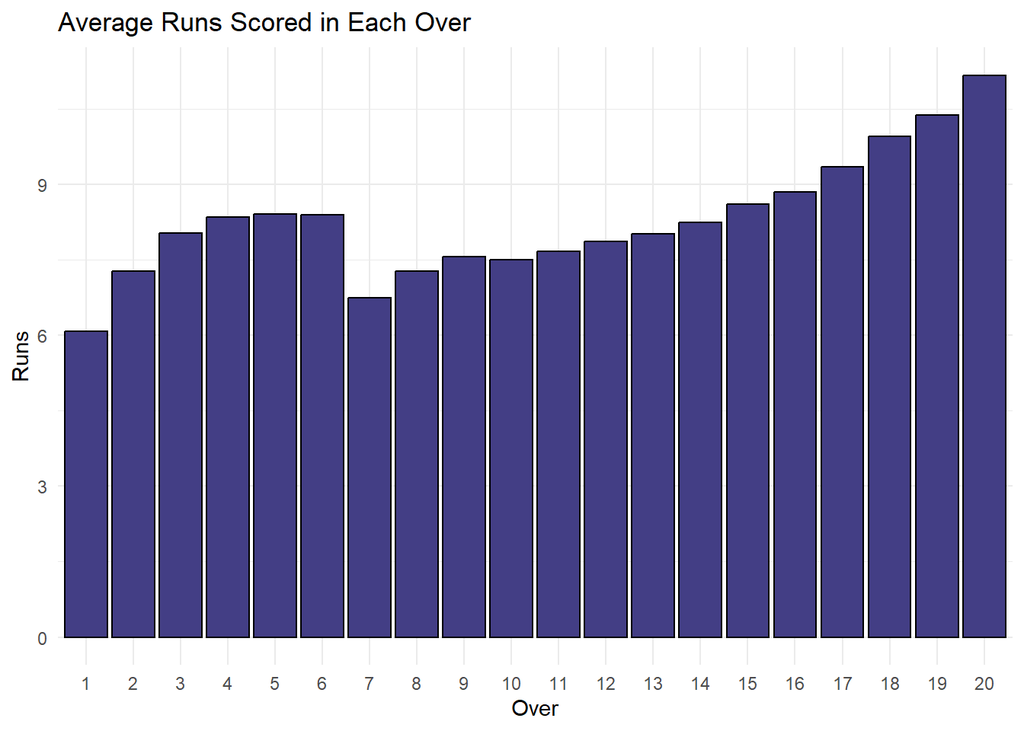

Figure 1: Average Runs Scored in Each Over

```r
summary1 <- ipl %>%
  group_by(over) %>%
  summarize(legal_ball_count = sum(!extra_ball),
            total_runs = sum(runs_off_bat + extras),
            average_runs_per_over = ((total_runs / legal_ball_count)*6))

ggplot(summary1, aes(x = factor(over), y = average_runs_per_over)) +
  geom_col(fill = viridis(12, option = "D")[3], color = "black", stat = "identity") +
  labs(x = "Over", y = "Runs", title = "Average Runs Scored in Each Over") +
  theme_minimal()
```

In this plot, we can see the average runs scored in each over of an IPL inning. The average runs scored in the 1st over is a little more than 6, and the average runs increase in the next few overs until the 6th over, where the average runs scored is about 8.25. We see a huge dip in the 7th over, where the average runs is about 7. This sudden decrease is due to the fact that powerplay restrictions are lifted after the end of the 6th over, and the fielding team can have as many as 4 fielders in the outer field. In the powerplay, the fielding team can only have up to 2 fielders in the outer field, which makes aggressive batting more preferable to the batters during that period. From the 7th over, the average runs keep increasing gradually . During the last few overs, the average runs scored in each over is really high, as batters worry less about getting out and start playing very aggressively.

### Relationship between Overs and Wickets

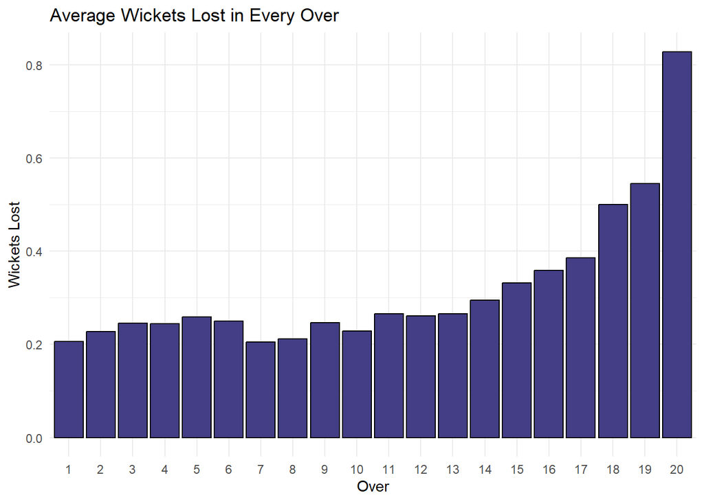

Figure 2: Average Wickets Lost in Every Over

```r
summary2 <- ipl %>%
  group_by(over) %>%
  summarize(legal_ball_count = sum(!extra_ball),
            total_wickets = sum(wicket),
            average_wickets_per_over = ((total_wickets / legal_ball_count)*6))

ggplot(summary2, aes(x = factor(over), y = average_wickets_per_over)) +
  geom_col(fill = viridis(12, option = "D")[3], color = "black", stat = "identity") +
  labs(x = "Over", y = "Wickets Lost", title = "Average Wickets Lost in Every Over") +
  theme_minimal()
```

In this plot, we can see the number of wickets lost on average in each over of an IPL game. From the 1st to the 13th over, teams lose somewhere between 0.2 to 0.3 wicket in an over, on average. However, this number keeps increasing from the 14th over. Especially in the 18th, 19th, and 20th over, the frequency of losing wickets is very high. This phenomenon can also be explained by the idea that batters are more willing to take risk in the last few overs of the inning, and in the process they score more runs but also lose more wickets.

### Average Runs Scored in Partnerships

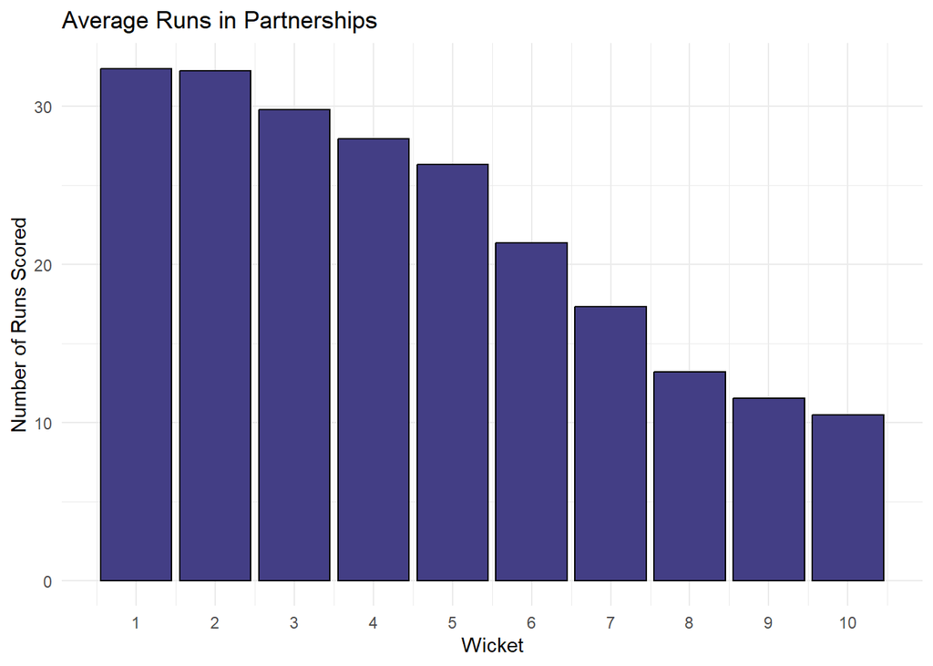

Figure 3: Average Runs in Partnerships

```r
result <- table(ipl$wickets_lost_yet[ipl$wicket == TRUE])

summary3 <- ipl %>%
  group_by(wickets_lost_yet) %>%
  summarize(total_runs = sum(runs_off_bat + extras))

summary3$n <- nrow(summary3)
summary3$total_runs[summary3$n - 1] <- summary3$total_runs[summary3$n - 1] + summary3$total_runs[summary3$n]

summary3 <- summary3[-summary3$n,]

summary3$n <- NULL

summary3 <- summary3 %>%
  mutate(wickets_lost_yet = wickets_lost_yet + 1) %>%
  mutate(average_runs_per_wicket = total_runs / as.numeric(result))

ggplot(summary3, aes(x = wickets_lost_yet, y = average_runs_per_wicket)) +
  geom_col(fill = viridis(12, option = "D")[3], color = "black", stat = "identity") +
  labs(x = "Wicket", y = "Number of Runs Scored", title = "Average Runs in Partnerships") +
  theme_minimal() +
  scale_x_continuous(breaks = 1:10)
```

In this plot, we can see the average runs scored in a partnership in an IPL inning. In the 1st wicket partnership, the two opening batters bat. Once one of them gets out, another batter replaces him and then begins the 2nd wicket partnership, and so forth. Since the first 7 to 8 players in a cricket team are specialized batters, we see that more runs are scored on average in the earlier partnerships. Since the last few players in a cricket team are specialized bowlers and hence are relatively worse in batting, the average runs scored in later partnerships are lower.

### Summary

From the plots, we see that the number of balls a team has left matters in their run scoring. If they have too many balls left, they would not want to play too aggressively and get out, whereas if they have fewer balls left, they have more incentive to take risks and score at a higher rate, since balls are limited resources in cricket and a team’s inning ends once the balls run out. We can also see that the number of wickets left also matters in a team’s approach to scoring. If a team runs out of wickets before finishing all their allotted balls, their inning would still end. This means a team has an incentive to not lose too many wickets early on in the inning. On top of that, not all wickets are equally important, as the players who bat earlier are generally better at batting, while the batters who bat later are generally weak batters since they specialize in bowling. Therefore, it makes sense that the exact number of balls and wickets that a team has left at any point in the game is crucial to judge how many additional runs they would score.

### Data Wrangling

```r
ipl <- mutate(ipl, wickets_remaining = 10 - wickets_lost_yet)
ipl<-mutate(ipl, innings_total = ifelse(innings == 1, innings1_total, innings2_total))
ipl<-mutate(ipl, runs_remaining = innings_total - runs_scored_yet)

const <- 1e-5

ipl$balls_remaining <- ipl$balls_remaining + const
ipl$wickets_remaining <- ipl$wickets_remaining + const
ipl$runs_remaining <- ipl$runs_remaining + const
```

We need to know how many wickets a team has left at any point in the game. Since the dataset does not contain that directly, we create a new variable called “wickets_remaining” from the variable “wickets_lost_yet”, which indicates the number of wickets a team has lost until that point. To create the new variable, we use the fact that a team has 10 wickets in total, so we subtract the number of wickets already lost from 10 to get the number of wickets left.

The dataset has the inning total for both inning in separate columns: “innings1_total” and “innings2_total”. We use an `ifelse` function to create one column for the inning total, where the value of any observation will indicate the inning total of the team batting at that point.

From the “innings_total” variable, we create a variable called “runs_remaining”, which indicates the additional runs the batting team scored from a certain point of the inning. To get this variabel, we subtract “runs_scored_yet”, the number of runs the team has already scored, from “innings_total”, the total runs they ended up scoring.

We intend to run a multivariate linear regression on “runs_remaining” using the variables “balls_remaining” and “wickets_remaining”. Since we have zeros in our observations of these variables, we have added a very small constant to every observation of the variable. Since the constant is very small compared to the values of the observations, this addition is not likely to significantly change our analysis.

# Statistical Analysis

## Welch Two Sample t-test

```r
ipl <- mutate(ipl, runs_scored_that_ball = runs_off_bat + extras)
subset1 <- ipl %>%
  filter(over >= 17 & over <= 20)
subset2 <- ipl %>%
  filter(over >= 7 & over <= 16)
t.test_result <- t.test(subset1$runs_scored_that_ball, subset2$runs_scored_that_ball, alternative = "greater")

t_test_details <- data.frame(
  Parameter = c("Statistic", "p-value", "Confidence Interval Lower", "Confidence Interval Upper", "Death Overs Average Runs", "Middle Overs Average Runs"),
  Value = c(
    sprintf("%.3f", t.test_result$statistic),
    format.pval(t.test_result$p.value, digits = 3),
    sprintf("%.3f", t.test_result$conf.int[1]),
    sprintf("%.3f", t.test_result$conf.int[2]),
    sprintf("%.3f", mean(subset1$runs_scored_that_ball, na.rm = TRUE)),
    sprintf("%.3f", mean(subset2$runs_scored_that_ball, na.rm = TRUE))
  )
)

kable(t_test_details, caption = "T-test Results: Runs Scored in Different Phases of the Inning", format = "html") %>%
  kable_styling(full_width = F,
                font_size = 10,
                position = 'center')
```

T-test Results: Runs Scored in Different Phases of the Inning

| Parameter | Value |
| --- | --- |
| Statistic | 35.947 |
| p-value | <2e-16 |
| Confidence Interval Lower | 0.327 |
| Confidence Interval Upper | Inf |
| Death Overs Average Runs | 1.609 |
| Middle Overs Average Runs | 1.266 |

Here, the null hypothesis is that the mean run scored in a ball between the 17th and the 20th over is smaller than or equal to the mean run scored in a ball between the 7th and the 16th over. The alternate hypothesis is that the mean run scored in a ball between the 17th and the 20th over is greater than the mean run scored in a ball between the 7th and the 16th over.

We can see that the p-value is smaller than 0.05, so we reject the null hypothesis. In 95% of cases, the difference between the mean run scored in a ball between the 17th and the 20th over and the mean run scored in a ball between the 7th and the 16th over is greater than 0.33. The mean run scored off a ball between the 17th and the 20th over is 1.61 and between the 7th and the 16th over is 1.27.

Therefore, there is statistically significant evidence that teams are more aggressive and score at a higher rate in the death overs (17th-20th over) than the middle overs (7th-16th over). This is an important finding, since in both cases there is no powerplay, so this difference in the rate of run scoring cannot be attributed to any sort of fielding restriction.

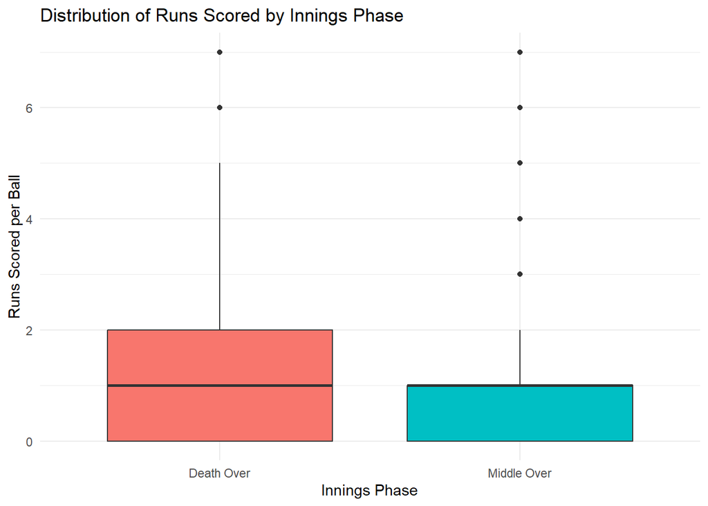

Figure 4: Distribution of Runs Scored in Middle Overs vs Death Overs

```r
box_data <- ipl %>%
  filter(over>=7)

box_data <- mutate(box_data, phase = ifelse(over>=17, "Death Over", "Middle Over"))

ggplot(box_data, aes(x = phase, y = runs_scored_that_ball, fill = phase)) +
  geom_boxplot() +
  labs(title = "Distribution of Runs Scored by Innings Phase",
       x = "Innings Phase",
       y = "Runs Scored per Ball") +
  theme_minimal() +
  theme(legend.position = "none")
```

Here, we can see that in both phases, the median run scored off a ball is the same, because 1 run is easy to score in cricket and in most deliveries that is the amount of run that is scored. However, the 75th percentile for death overs is higher than the middle overs. This is because batters play more aggressively, so they take doubles (that is, 2 runs off a ball) than they would in the middle overs.

## Multivariate Linear Regression

### Checking for Multicollinearity

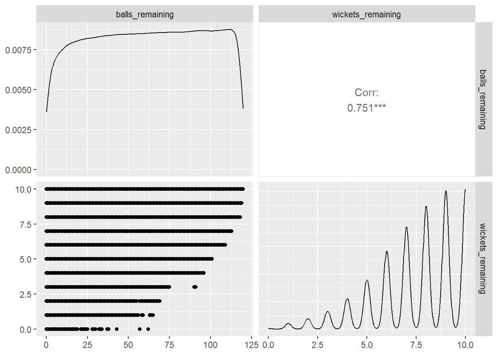

```r
ipl_subset <- ipl %>%
  select(balls_remaining, wickets_remaining)
ggpairs(ipl_subset)
```

From the plots, we can see the two variables “balls_remaining” and “wickets_remaining” are correlated to each other. Specifically, their correlation coefficient is 0.751, which is statistically significant and indicates there is a positive linear relationship between these variables. This makes sense, since as balls_remaining decreases, wickets_remaining should decrease too on average, as a team is likely to have lost more wickets if they have played more balls. Despite this somewhat high correlation, we proceed to use both of these variables in our linear regression model, because from our data exploration we have seen that both of these variables are important and can explain the potential runs a team can score from any point in the game.

### Running the Regression Model

```r
model <- lm(log(runs_remaining)~log(balls_remaining)+log(wickets_remaining), ipl)
regz <- list(`Effects of the Number of Balls Left and Wickets Left on Runs Scored` = model)
coefz<- c("(Intercept)" = "Constant", "log(balls_remaining)" = "Balls Left", "log(wickets_remaining)" = "Wickets Left")
gofz <- c("nobs", "r.squared", "adj.r.squared")
modelsummary(regz, estimate = c("{estimate}{stars} [{conf.low}, {conf.high}]"), gof_map = gofz, coef_map = coefz,
title = "Effect of the Number of Balls Left and Wickets Left on Runs Scored")
```

Effect of the Number of Balls Left and Wickets Left on Runs Scored

|  | Effects of the Number of Balls Left and Wickets Left on Runs Scored |
| --- | --- |
| Constant | −1.173*** [−1.191, −1.155] |
|  | (0.009) |
| Balls Left | 0.947*** [0.944, 0.951] |
|  | (0.002) |
| Wickets Left | 0.800*** [0.791, 0.810] |
|  | (0.005) |
| Num.Obs. | 243817 |
| R2 | 0.673 |
| R2 Adj. | 0.673 |

Here, we run a multivariate linear regression model, where the dependent variable is “runs_remaining” and the independent variables are “balls_remaining” and “wickets_remaining”. To get a better model, we have decided to log all the variables.

The coefficient of balls left is 0.947, which means if the number of balls left increases by 1%, the additional runs scored will increase by 0.947%. This makes sense, as a team are likely to score more runs if they have more balls left, all other things equal. The coefficient of wickets left is 0.800, which means if the number of balls left increases by 1%, the additional runs scored will increase by 0.800%. This also makes sense, as a team is likely to score more runs if they have more wickets left, all other things equal. The p-value is very small for the coefficients, so the results are statistically significant.

The adjusted R2 is 0.673, which means the variables “balls_remaining” and “wickets_remaining” account for 67.3% of the variation in the variable “runs_remaining”.

### Diagnostics

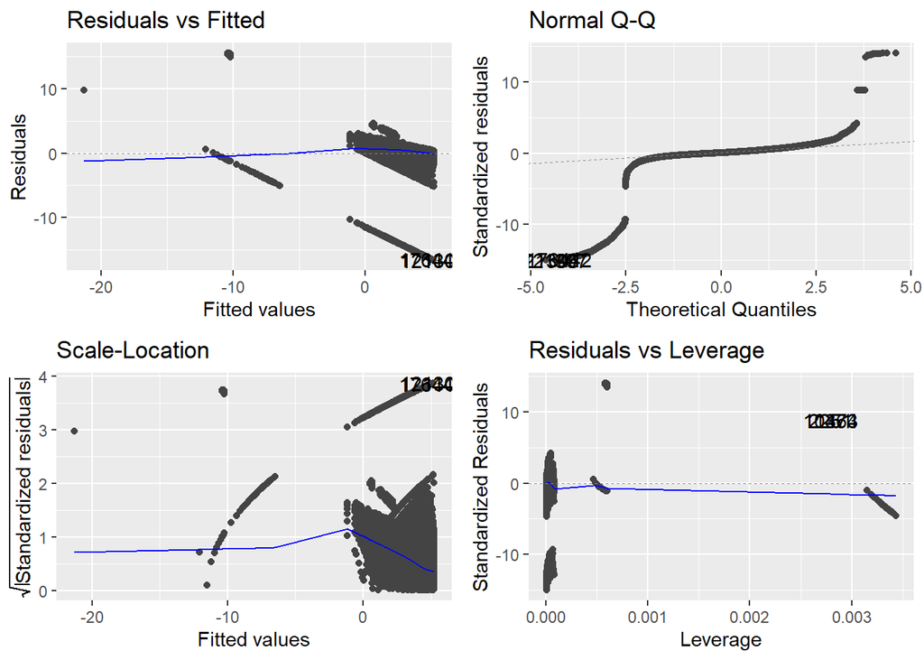

```r
autoplot(model)
```

In the residuals vs fitted plot, the points do not quite bounce around the y=0 line randomly, as there are points that are far away from the y=0 line. This means there is not a perfectly linear relationship between the independent variables and the dependent variable. In the QQ plot, the points for the most part fall along the dashed line. However, even here a lot of points deviate from the dashed line. So, the residuals are somewhat normally distributed, but not perfectly normally distributed. In the Scale-Location plot, the variance is not constant across the fitted values. This undermines the assumption that the variance of the residuals is constant. In the Residual vs Leverage plot, we can spot some outliers.

All this indicates that our model does not perfectly fulfill the linear regression assumptions.

### Prediction

```r
newdata <- data.frame(
  balls_remaining = c(60, 50, 40, 30, 20),
  wickets_remaining = c(8, 8, 7, 4, 7)
)
prediction <- predict(model, newdata)
predicted_runs <- exp(prediction)
results_table <- data.frame(newdata, Predicted_Runs = predicted_runs)
table_output <- kable(results_table, format = "html", col.names = c("Balls Remaining", "Wickets Remaining", "Predicted Runs"), align = c('c', 'c', 'c')) %>%
  kable_styling(full_width = F,
                font_size = 10,
                position = 'center')
table_output
```

| Balls Remaining | Wickets Remaining | Predicted Runs |
| --- | --- | --- |
| 60 | 8 | 79.00153 |
| 50 | 8 | 66.47089 |
| 40 | 7 | 48.35359 |
| 30 | 4 | 23.52890 |
| 20 | 7 | 25.07724 |

Here, we use the linear model to predict the additional runs a team can score from different game situations. The predictions seem reasonable. For example, if a team has 30 balls and only 4 wickets left, they would score about 23 runs. But they would score almost the same amount of runs in fewer balls if they have more wickets left. Due to a having more wickets in hand, they have better batters batting on the crease, and they can play fearlessly and aggressively in the last few overs.

# Conclusion

We encountered several limitations in our study. The primary challenge was the inherent non-linear nature of cricket outcomes, which may not be fully captured by linear regression models. Additionally, the presence of zero values in our dataset required the introduction of a small constant to facilitate logarithmic transformation, which could introduce minor inaccuracies in our model predictions. Despite these limitations, our model achieved an adjusted R2 of 0.673, indicating that it could explain approximately 67.3% of the variance in the runs remaining based on the balls and wickets left.

# References

- Cricket Equipment USA. (n.d.). Cricket explained: A guide. Retrieved May 2, 2024, from https://www.cricketequipmentusa.com/cricket-explained-a-guide-41
- Grolemund, G., & Wickham, H. (n.d.). R for data science: Introduction. Retrieved from https://r4ds.had.co.nz/introduction.html
- Jhanwar, M. G., & Pudi, V. (2016). Predicting the Outcome of ODI Cricket Matches: A Team Composition Based Approach. MLSA@PKDD/ECML.
- Kampakis, S., & Thomas, W. (2015). Using machine learning to predict the outcome of English county twenty over cricket matches. arXiv preprint arXiv:1511.05837.
- Tran, H. R., & J. (2022, October 18). Cricketdata: An open source R package. Retrieved from https://cran.r-project.org/web/packages/cricketdata/vignettes/cricketdata_R_pkg.html